# Section 13: Principal Components Analysis

Pablo Arés Gastesi

2026-07-07

# 1 Introduction

Every method so far in this course has been **supervised**: we had a response variable (a class or a number) that the model was trying to predict, and we judged the model by how well it did so. **Principal Components Analysis (PCA)** is different — it is **unsupervised**: there is no response, only a set of predictors, and the goal is to understand and summarise the structure of the predictors themselves.

PCA constructs new variables — the **principal components** — as linear combinations of the original ones, chosen so that the first component captures as much of the variance (information) in the data as possible, the second captures as much of the *remaining* variance as possible while being uncorrelated with the first, and so on. In this sense PCA resembles discriminant analysis (Section 7): both build new variables as linear combinations of the originals. The difference is the objective — LDA builds combinations that best *separate known classes*; PCA builds combinations that best *explain the variance* of the data, with no classes involved at all.

Once we have two or three components that capture most of the information, we can use them as inputs to regression, classification, or clustering, or simply to visualise and understand how the original variables relate to one another. This makes PCA one of the standard tools for **dimension reduction**.

Further reading: [ISLR2 Section 12.2](https://www.statlearning.com/) covers PCA in depth, including its use for regression (principal components regression).

# 2 The geometry of PCA

## 2.1 Projecting onto a line

Suppose our variables are $x_1, x_2, \ldots, x_n$. PCA looks for a line through the origin, $a_1 x_1 + a_2 x_2 + \cdots + a_n x_n = 0$, subject to $a_1^2 + a_2^2 + \cdots + a_n^2 = 1$ (so the scale of the coefficients is fixed and comparable). Given such a line, every data point $p$ can be **projected** onto it — dropping a perpendicular from $p$ to the line — to get a point $q$.

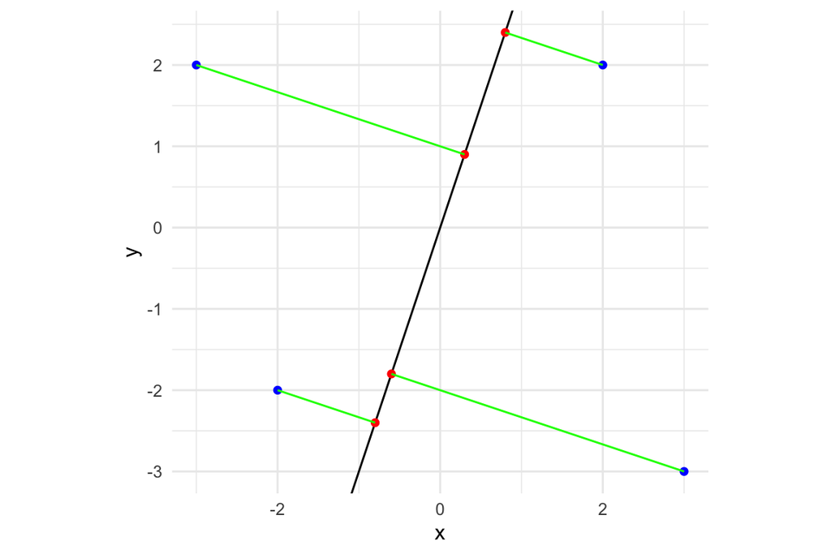

Figure 2.1: Four points (blue) projected onto a candidate line of slope 3 (red points, green segments)

```r
datos <- data.frame(x = c(2, 3, -2, -3), y = c(2, -3, -2, 2))

project_onto <- function(slope, a, b) (a + slope * b) / (1 + slope^2)

slope_try <- 3
datos$xproj <- project_onto(slope_try, datos$x, datos$y)
datos$yproj <- datos$xproj * slope_try

ggplot(datos) +
  geom_abline(slope = slope_try, intercept = 0) +
  geom_point(aes(x = x, y = y), colour = "blue") +
  geom_point(aes(x = xproj, y = yproj), colour = "red") +
  geom_segment(aes(x = x, y = y, xend = xproj, yend = yproj), colour = "green") +
  coord_fixed() +
  labs(x = "x", y = "y") +
  theme_minimal()
```

## 2.2 Why “maximise variance” means “minimise projection distance”

The length of a projected point $q = (a,b)$ is $\lVert q \rVert^2 = a^2 + b^2$, and the (sample) variance of the projections is proportional to $\sum_i \lVert q_i \rVert^2$. We want a line that makes this quantity as large as possible. The key geometric fact is Pythagoras’ theorem applied to the right triangle formed by a point $p$, its projection $q$, and the origin:

$$\lVert p \rVert^2 = \lVert q \rVert^2 + \lVert pq \rVert^2$$

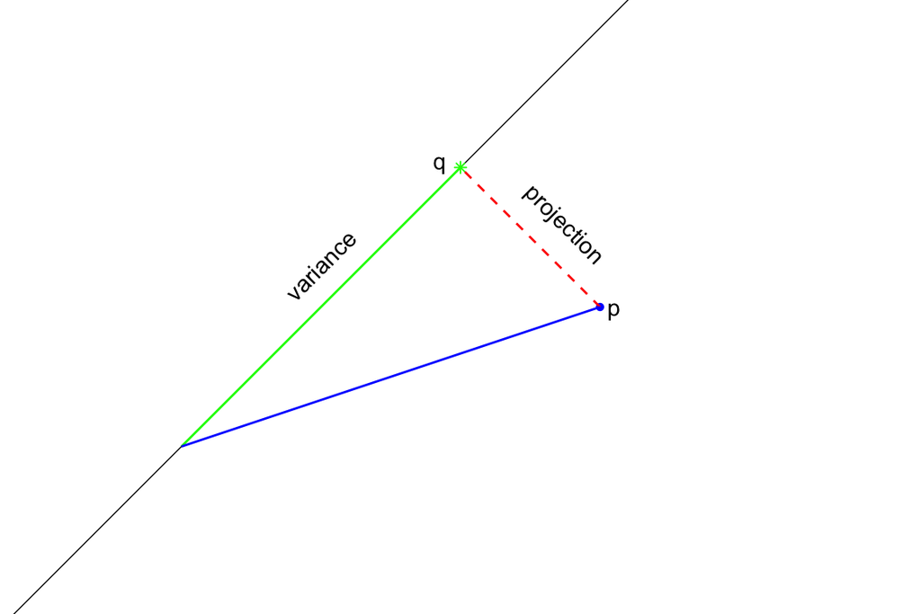

Figure 2.2: p is fixed; maximising the variance (length of q) is the same as minimising the projection distance pq

```r
ggplot() +
  geom_abline(slope = 1, intercept = 0, colour = "black", linewidth = 0.25) +
  coord_fixed() +
  expand_limits(x = c(-1, 5), y = c(-1, 3)) +
  geom_point(aes(x = 3, y = 1), colour = "blue", pch = 16) +
  geom_point(aes(x = 2, y = 2), colour = "green", pch = 8) +
  geom_segment(aes(x = 3, y = 1, xend = 2, yend = 2), lty = 2, colour = "red") +
  geom_segment(aes(x = 0, y = 0, xend = 2, yend = 2), colour = "green") +
  geom_segment(aes(x = 0, y = 0, xend = 3, yend = 1), colour = "blue", linewidth = 0.5) +
  annotate("text", x = 1,    y = 1.3, label = "variance",   angle = 45)  +
  annotate("text", x = 2.75, y = 1.6, label = "projection", angle = -45) +
  annotate("text", x = 1.85, y = 2.05, label = "q") +
  annotate("text", x = 3.1,  y = 1,   label = "p") +
  theme_void()
```

Since $\lVert p \rVert$ (the blue segment) is fixed by the data, making $\lVert q \rVert$ (the green segment, our variance) as large as possible is exactly the same problem as making $\lVert pq \rVert$ (the red segment, the projection error) as small as possible. So PCA can be described two equivalent ways: find the line that captures the most variance, or find the line that minimises the total (perpendicular) distance from the data to the line.

## 2.3 PCA is not regression

This second description makes it tempting to confuse PCA with a regression line, but they minimise **different** distances.

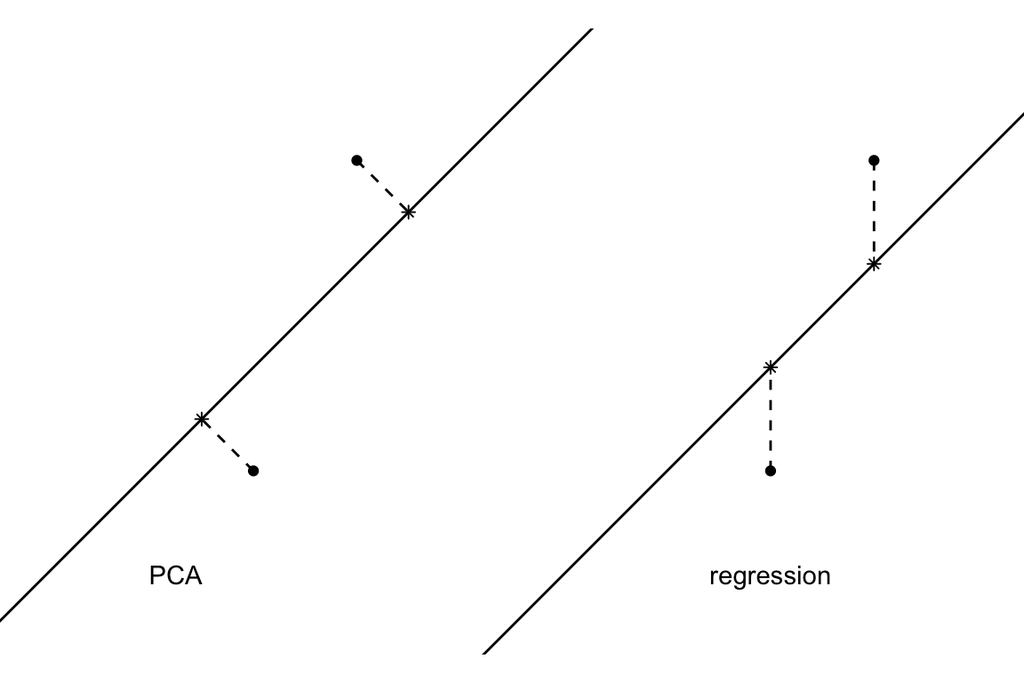

Figure 2.3: PCA minimises the perpendicular distance to the line (left); regression minimises the vertical distance (right)

```r
ggplot() +
  coord_fixed() +
  geom_abline(intercept = 0, slope = 1, linewidth = 0.5) +
  expand_limits(x = c(0, 9), y = c(-0.5, 5)) +
  geom_point(aes(x = c(2, 3), y = c(1, 4))) +
  geom_segment(aes(x = c(2, 3), y = c(1, 4), xend = c(1.5, 3.5), yend = c(1.5, 3.5)), lty = 2) +
  geom_point(aes(x = c(1.5, 3.5), y = c(1.5, 3.5)), pch = 8) +
  geom_abline(intercept = -5, slope = 1) +
  geom_point(aes(x = c(7, 8), y = c(1, 4))) +
  geom_segment(aes(x = c(7, 8), y = c(1, 4), xend = c(7, 8), yend = c(2, 3)), lty = 2) +
  geom_point(aes(x = c(7, 8), y = c(2, 3)), pch = 8) +
  annotate("text", x = 1.25, y = 0, label = "PCA") +
  annotate("text", x = 7,    y = 0, label = "regression") +
  theme_void()
```

Ordinary regression minimises **vertical** distances (the error in predicting $y$ from $x$); it treats $x$ and $y$ asymmetrically. PCA minimises **perpendicular** distances, treating all variables symmetrically — there is no designated response. This is consistent with PCA being unsupervised: it has no particular variable it is trying to predict.

# 3 A worked example

Standardising the data before running PCA is just as important as it was for KNN (Section 10) — PCA also depends on the scale of the variables, since a variable with a larger numeric range will dominate the variance calculation regardless of how informative it actually is. `prcomp()` has a built-in `scale` option for this.

```r
datos <- data.frame(x = c(2, 3, -2, -3), y = c(2, -3, -2, 2))
components_scale <- prcomp(datos, scale = TRUE)
components_scale
```

```
## Standard deviations (1, .., p=2):
## [1] 1.1407768 0.8358399
##
## Rotation (n x k) = (2 x 2):
##          PC1       PC2
## x -0.7071068 0.7071068
## y  0.7071068 0.7071068
```

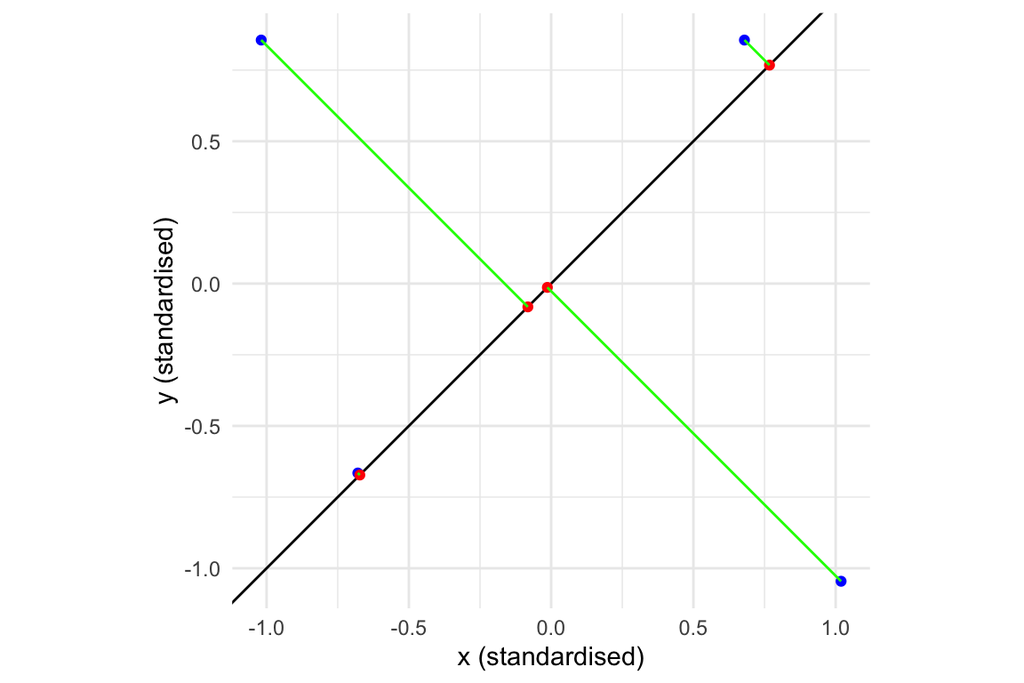

```r
datos_std <- as.data.frame(scale(datos))
slope_pc1 <- 1
datos_std$xproj <- project_onto(slope_pc1, datos_std$x, datos_std$y)
datos_std$yproj <- datos_std$xproj * slope_pc1

ggplot(datos_std) +
  geom_abline(slope = slope_pc1, intercept = 0) +
  geom_point(aes(x = x, y = y), colour = "blue") +
  geom_point(aes(x = xproj, y = yproj), colour = "red") +
  geom_segment(aes(x = x, y = y, xend = xproj, yend = yproj), colour = "green") +
  coord_fixed() +
  labs(x = "x (standardised)", y = "y (standardised)") +
  theme_minimal()
```

# 4 PCA on the iris data

We now apply PCA to a real, higher-dimensional dataset: the four numeric measurements in `iris` (we drop the fifth column, `Species`, since PCA does not use — or need — the class labels at all).

```r
components_iris <- prcomp(iris[, -5], scale = TRUE)
components_iris
```

```
## Standard deviations (1, .., p=4):
## [1] 1.7083611 0.9560494 0.3830886 0.1439265
##
## Rotation (n x k) = (4 x 4):
##                     PC1         PC2        PC3        PC4
## Sepal.Length  0.5210659 -0.37741762  0.7195664  0.2612863
## Sepal.Width  -0.2693474 -0.92329566 -0.2443818 -0.1235096
## Petal.Length  0.5804131 -0.02449161 -0.1421264 -0.8014492
## Petal.Width   0.5648565 -0.06694199 -0.6342727  0.5235971
```

Each column of the **rotation matrix** gives the loadings of one principal component — the weight it puts on each original variable. For example, the first component is

$$\text{PC1} = 0.521\,\text{Sepal.Length} - 0.269\,\text{Sepal.Width} + 0.580\,\text{Petal.Length} + 0.565\,\text{Petal.Width}$$

## 4.1 Visualising the components

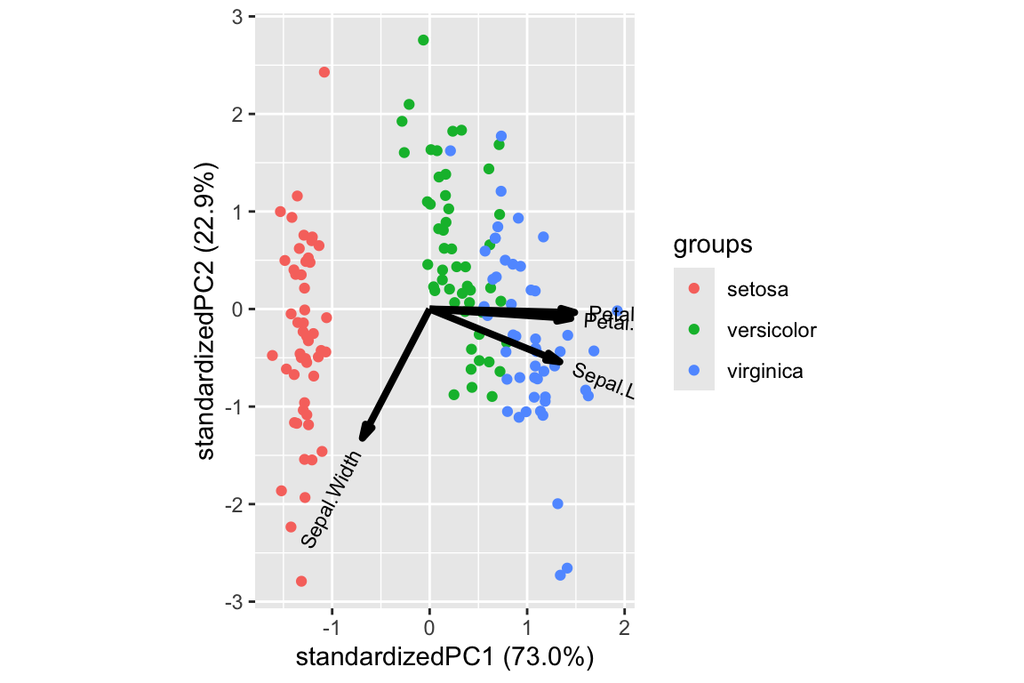

Figure 4.1: Biplot of the first two principal components, coloured by species

```r
ggbiplot(components_iris, groups = iris$Species)
```

The **biplot** overlays two things: the projected data points (in the space of PC1 and PC2) and arrows showing how each original variable loads onto those two components. Species separate quite well along PC1 alone, and the petal measurements (long arrows, similar direction) contribute the most to it.

## 4.2 How much variance does each component explain?

```r
summary(components_iris)
```

```
## Importance of components:
##                           PC1    PC2     PC3     PC4
## Standard deviation     1.7084 0.9560 0.38309 0.14393
## Proportion of Variance 0.7296 0.2285 0.03669 0.00518
## Cumulative Proportion  0.7296 0.9581 0.99482 1.00000
```

The `summary()` output reports **standard deviations**, not variances — to get variance we must square them. The total variance across all four (standardised) variables is:

```r
sum(components_iris$sdev^2)
```

```
## [1] 4
```

This equals 4 because we standardised every variable to have variance 1, so the four original variables together contribute exactly 4 units of variance. The variance captured by the first component alone is:

```r
components_iris$sdev[1]^2
```

```
## [1] 2.918498
```

and its proportion of the total is:

```r
components_iris$sdev[1]^2 / sum(components_iris$sdev^2)
```

```
## [1] 0.7296245
```

matching the “Proportion of Variance” reported for PC1 in `summary()` above: roughly 73%. Adding PC2 brings the cumulative proportion to around 96%, so just two of the four components already capture almost all the information in the original four measurements.

## 4.3 Choosing how many components to keep

A **scree plot** shows the variance (or standard deviation) explained by each successive component, and is the usual visual tool for deciding how many components are worth keeping — look for an “elbow” where the curve flattens out.

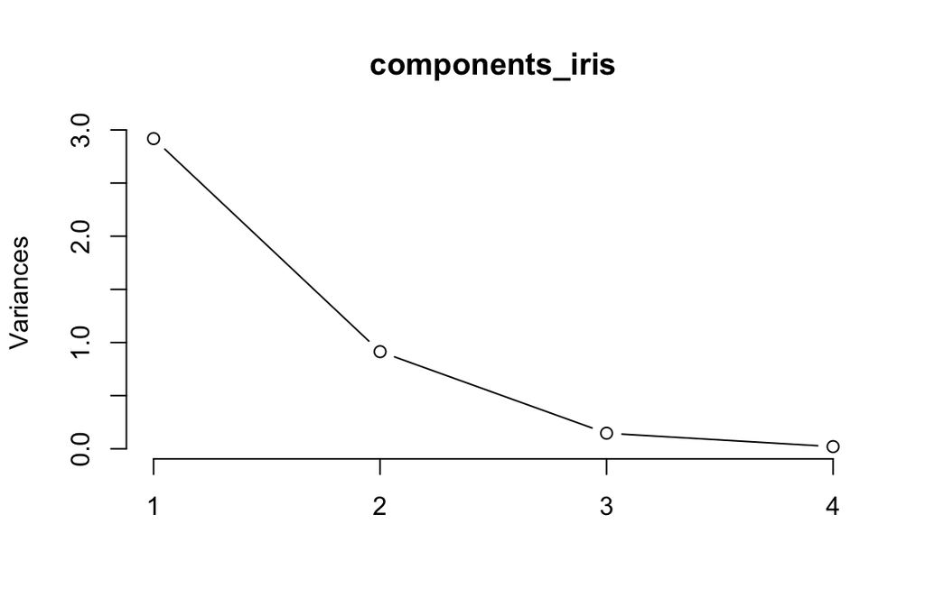

```r
plot(components_iris, type = "l")
```

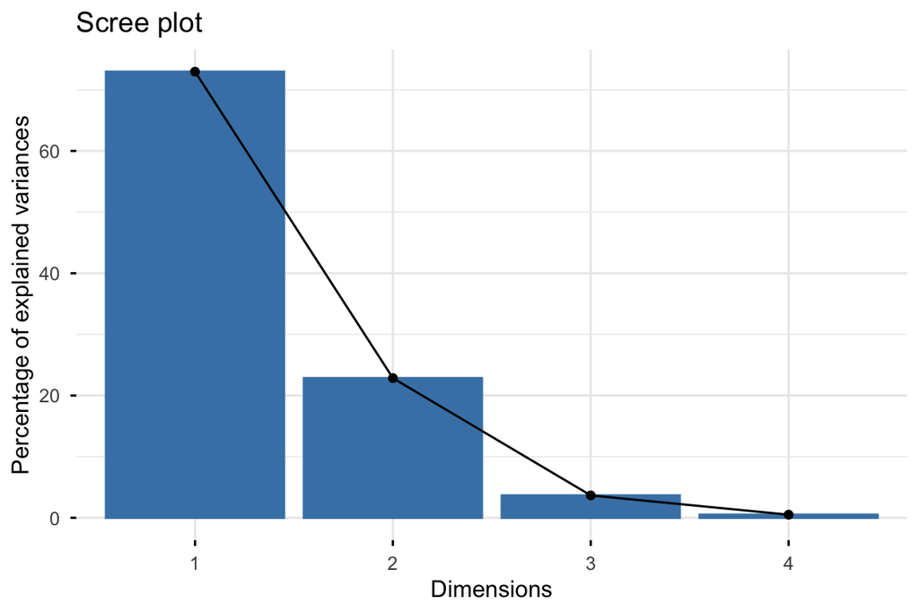

Figure 4.3: Scree plot as percentage of variance explained (factoextra)

```r
fviz_eig(components_iris)
```

An alternative, more formal rule is the **Kaiser criterion**: each component is associated with an **eigenvalue** of the correlation matrix (equal to its variance, since we standardised the data), and the rule of thumb is to keep every component whose eigenvalue exceeds 1 — i.e. every component that explains more variance than a single original (standardised) variable would on its own.

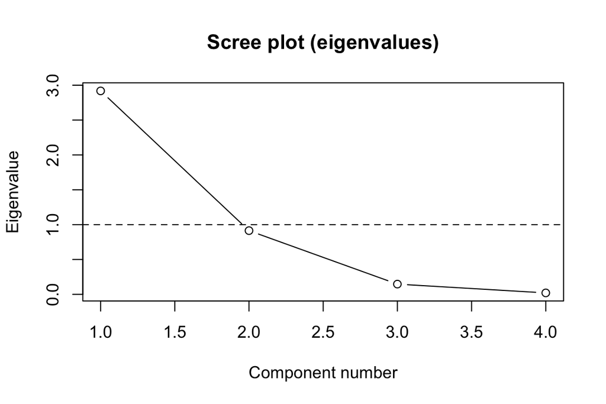

Figure 4.4: Eigenvalues of the correlation matrix, with the Kaiser cutoff at 1

```r
eigenvalues <- eigen(cor(iris[, -5]))$values
plot(eigenvalues, main = "Scree plot (eigenvalues)",
    xlab = "Component number", ylab = "Eigenvalue", type = "b")
abline(h = 1, lty = 2)
```

By the Kaiser rule only the first component would be retained here — a reminder that different rules of thumb (elbow in the scree plot vs. eigenvalue > 1) do not always agree exactly, and both should be treated as guides rather than hard laws.

## 4.4 A richer biplot

`factoextra`’s `fviz_pca_biplot()` combines the individuals (points, coloured by species with confidence ellipses) and the variable loadings (arrows, coloured by how much they contribute to the plotted components) in one figure:

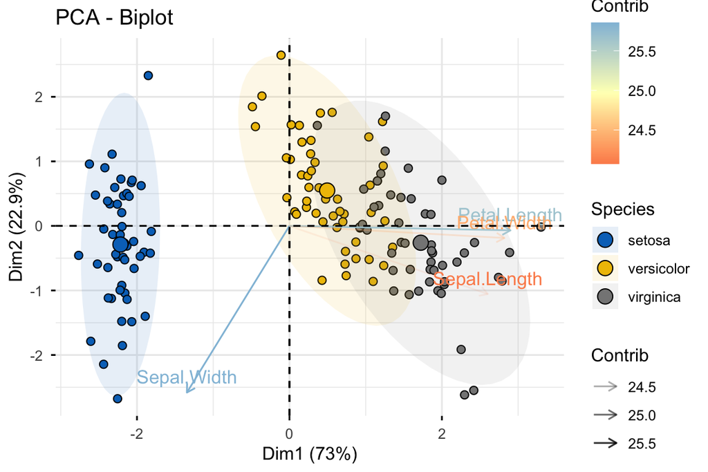

Figure 4.5: Individuals and variable contributions, iris data

```r
fviz_pca_biplot(components_iris,
                geom.ind = "point",
                fill.ind = iris$Species, col.ind = "black",
                pointshape = 21, pointsize = 2,
                palette = "jco",
                addEllipses = TRUE,
                alpha.var = "contrib", col.var = "contrib",
                gradient.cols = "RdYlBu",
                legend.title = list(fill = "Species", color = "Contrib",
                                    alpha = "Contrib"))
```

# 5 A second example: USArrests

`USArrests` records, for each US state, the rate of murder, assault, and rape arrests (per 100,000) and the percentage of the population living in urban areas. These variables are on very different scales (percentages vs. arrest rates), so — as always with PCA — we standardise first.

```r
components_crime <- prcomp(USArrests, scale = TRUE)
```

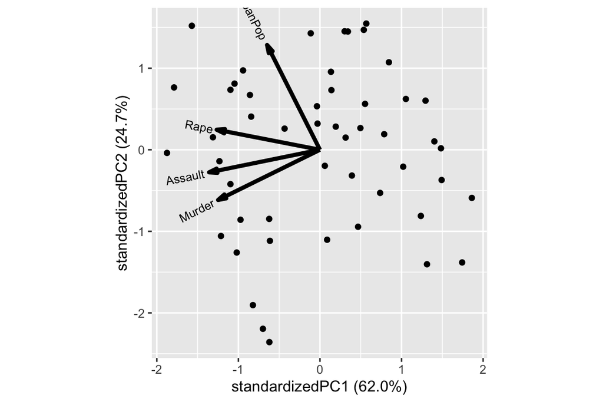

Figure 5.1: Biplot of US states by crime statistics

```r
ggbiplot(components_crime)
```

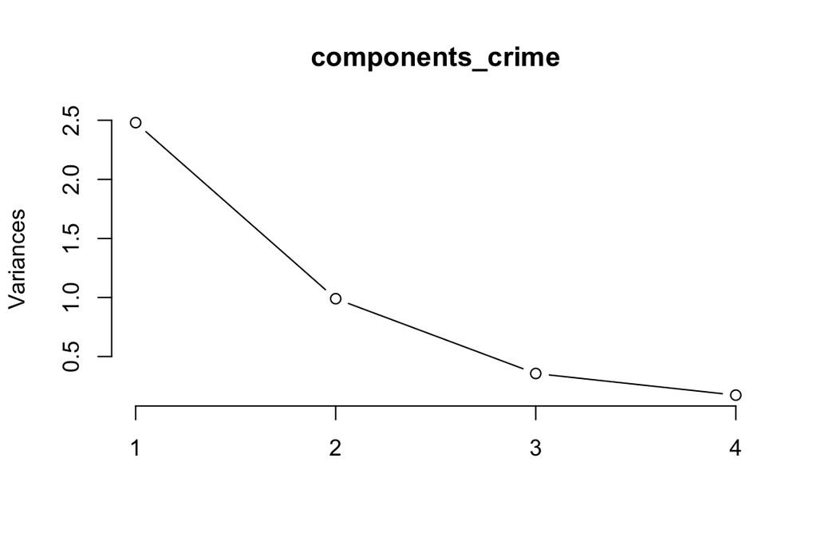

Figure 5.2: Scree plots for the USArrests components

```r
plot(components_crime, type = "l")
```

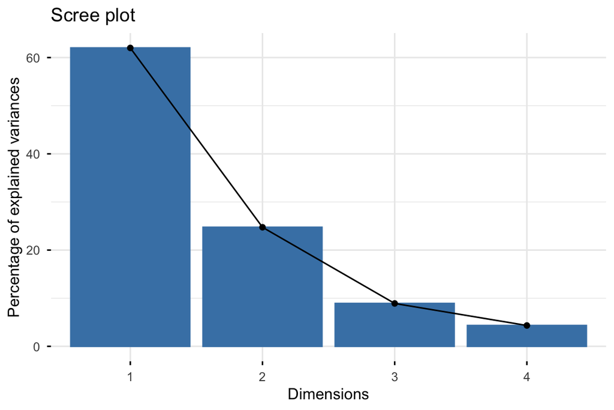

Figure 5.3: Scree plots for the USArrests components

```r
fviz_eig(components_crime)
```

The three crime-rate variables (murder, assault, rape) tend to load together on the first component — states with one tend to have the others — while urban population tends to load more heavily on the second, separating “how urban” a state is from “how much violent crime” it has.

# 6 Summary

- PCA is **unsupervised**: it has no response variable and does not use class labels, even when they exist (contrast with LDA in Section 7, which is supervised and uses classes directly).
- Each principal component is a linear combination of the original variables, chosen to capture as much of the remaining variance as possible while staying uncorrelated with previous components (equivalent to minimising the perpendicular projection distance — Pythagoras again).
- **Always standardise** (`scale = TRUE`) before running PCA unless every variable is already on a comparable scale — otherwise variables with larger numeric ranges will dominate purely because of their units.
- `summary()` reports standard deviations; square them to get variances and proportions of variance explained.
- Use a scree plot (elbow) or the Kaiser criterion (eigenvalue > 1) as guides — not hard rules — for how many components to retain.

| Concept | Function | Notes |
| --- | --- | --- |
| Fit PCA | `prcomp(data, scale = TRUE)` | always standardise unless variables are already comparable |
| Variance explained | `summary(fit)` | reports standard deviations — square for variance |
| Component loadings | `fit$rotation` | weight of each original variable on each component |
| Scree plot | `plot(fit, type = "l")` or `factoextra::fviz_eig(fit)` | look for the “elbow” |
| Kaiser criterion | `eigen(cor(data))$values > 1` | keep components with eigenvalue above 1 |
| Biplot | `ggbiplot::ggbiplot(fit)` or `factoextra::fviz_pca_biplot(fit)` | points + variable loading arrows together |

Key takeaway: PCA re-expresses correlated variables as a smaller number of uncorrelated components ranked by how much variance they explain, trading some interpretability (components are combinations of all original variables, not a single one) for a compact summary that can be visualised, screened for redundancy, and fed into other models.